# Project Brain Tumor Detection Using Convolutional Neural Networks (CNN)

## by: Neemias Moreira

# Project Overview

Brain tumors are abnormal growths of cells in the brain that can be life-threatening. Early detection of brain tumors using MRI scans can significantly improve treatment outcomes.

This project leverages deep learning to classify MRI brain scans into tumor (yes) or no tumor (no) categories. The goal is to develop an automated and accurate model to assist in brain tumor detection using computer vision techniques.

A Convolutional Neural Network (CNN) was trained on a dataset of MRI scans and evaluated based on accuracy, precision, recall, and F1-score. The model was then used to predict and visualize results on test images.

Overall, this project aims to develop an AI-powered image classification model using Convolutional Neural Networks (CNNs) to detect brain tumors in MRI images automatically.

```python
#Libraries
import os
import numpy as np
import matplotlib.pyplot as plt
import cv2
from tensorflow.keras.preprocessing.image import ImageDataGenerator
from PIL import Image
from sklearn.model_selection import train_test_split
from tensorflow.keras.preprocessing.image import img_to_array
import tensorflow as tf
from tensorflow.keras.models import Sequential
from tensorflow.keras.layers import Conv2D, MaxPooling2D, Flatten, Dense, Dropout, BatchNormalization
from tensorflow.keras.optimizers import Adam, SGD, RMSprop
from tensorflow.keras.callbacks import EarlyStopping
import shutil
from sklearn.metrics import classification_report, confusion_matrix
import seaborn as sns
from tensorflow.keras.layers import Conv2D, MaxPooling2D, Flatten, Dense, Dropout
import random
```

```python
#path to the dataset containing the images
dataset_path = r"C:/data/brain_tumor_dataset"
```

```python
#Defining a img size
IMG_SIZE = 150

# Load images in the data set
def load_images(dataset_path):
    categories = ["Yes", "No"]
    data = []

    for category in categories:
        path = os.path.join(dataset_path, category)
        label = categories.index(category)  # Yes=0, No=1

        for img_name in os.listdir(path):
            img_path = os.path.join(path, img_name)
            try:
                img = cv2.imread(img_path, cv2.IMREAD_GRAYSCALE)  # Convert to grayscale
                img = cv2.resize(img, (IMG_SIZE, IMG_SIZE))  # Resize images
                data.append([img, label])
            except Exception as e:
                print(f"Error loading image {img_name}: {e}")

    return data

data = load_images(dataset_path)
```

```python
# Shuffle and split data
np.random.shuffle(data)
X, y = zip(*data)
X = np.array(X).reshape(-1, IMG_SIZE, IMG_SIZE, 1) / 255.0  # Normalize
y = np.array(y)

print(f"Dataset Loaded: {len(X)} images")
```

```
Dataset Loaded: 253 images
```

Checking if the images are proprely load into the jupyter notebook.

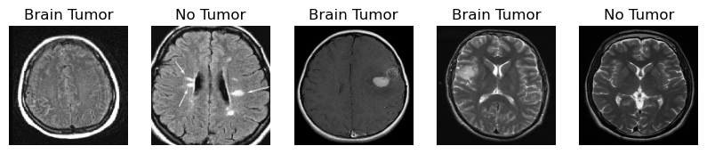

```python
# Define class labels
categories = ["Brain Tumor", "No Tumor"]

# Visualize sample images
def plot_sample_images(X, y, num_samples=5):
    plt.figure(figsize=(10, 5))
    for i in range(num_samples):
        plt.subplot(1, num_samples, i+1)
        plt.imshow(X[i].squeeze(), cmap='gray')  # Squeeze removes extra dimensions
        plt.title(categories[y[i]])
        plt.axis("off")
    plt.show()

# Display 5 sample images
plot_sample_images(X, y, num_samples=5)
```

### As MRI images may have different brightness levels due to machine settings or patient conditions.

### We can analyze this by calculating histograms of pixel intensity

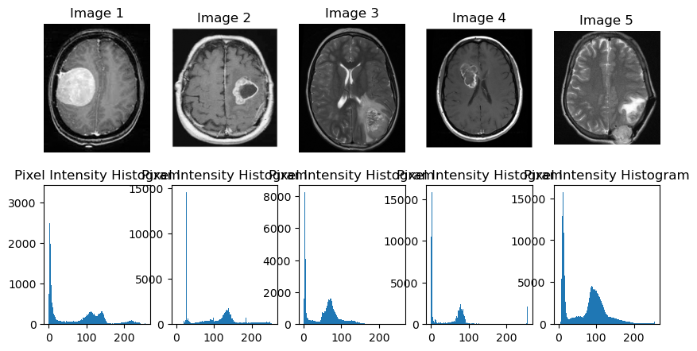

```python
# Function to plot histograms of sample images on yes data set
def plot_image_histograms(dataset_path, category, num_samples=5):
    category_path = os.path.join(dataset_path, category)
    image_files = os.listdir(category_path)[:num_samples]

    plt.figure(figsize=(10, 5))
    for i, img_file in enumerate(image_files):
        img_path = os.path.join(category_path, img_file)
        img = cv2.imread(img_path, cv2.IMREAD_GRAYSCALE)  # Convert to grayscale

        plt.subplot(2, num_samples, i+1)
        plt.imshow(img, cmap='gray')
        plt.axis("off")
        plt.title(f"Image {i+1}")

        plt.subplot(2, num_samples, num_samples + i+1)
        plt.hist(img.ravel(), bins=256, range=[0, 256])
        plt.title("Pixel Intensity Histogram")

    plt.show()

# Analyze brightness for "Yes" (tumor) images
dataset_path = r"C:/data/brain_tumor_dataset"  # Update with your actual dataset path
plot_image_histograms(dataset_path, "yes", num_samples=5)
```

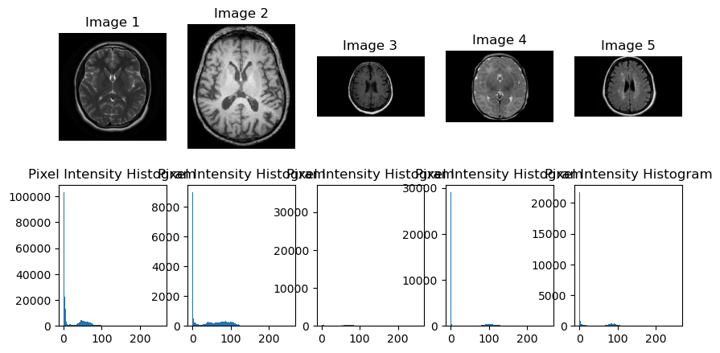

```python
# Function to plot histograms of sample images on no data set
def plot_image_histograms(dataset_path, category, num_samples=5):
    category_path = os.path.join(dataset_path, category)
    image_files = os.listdir(category_path)[:num_samples]

    plt.figure(figsize=(10, 5))
    for i, img_file in enumerate(image_files):
        img_path = os.path.join(category_path, img_file)
        img = cv2.imread(img_path, cv2.IMREAD_GRAYSCALE)  # Convert to grayscale

        plt.subplot(2, num_samples, i+1)
        plt.imshow(img, cmap='gray')
        plt.axis("off")
        plt.title(f"Image {i+1}")

        plt.subplot(2, num_samples, num_samples + i+1)
        plt.hist(img.ravel(), bins=256, range=[0, 256])
        plt.title("Pixel Intensity Histogram")

    plt.show()

# Analyze brightness for "No" (tumor) images
dataset_path = r"C:/data/brain_tumor_dataset"  # Update with your actual dataset path
plot_image_histograms(dataset_path, "no", num_samples=5)
```

### Since the pixels are not well distributed in the histogram, which shows there's a low contrats which can harm my model later to do predictions I choose to use histogram equalization to adjusts the contrast of the image by redistributing the intensity values, which can make the details in dark or light regions more visible. This helps improve visibility in images with low contrast.

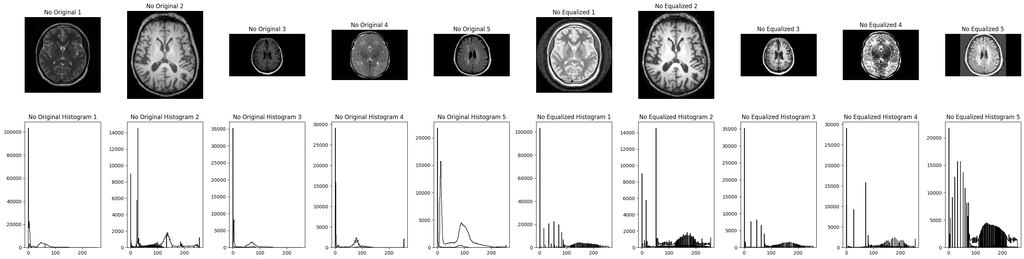

```python
# Define the histogram equalization function
def apply_histogram_equalization(image):
    # Convert the image to a NumPy array (if it's a PIL image)
    image_data = np.array(image)

    # Apply histogram equalization
    equalized_image = cv2.equalizeHist(image_data)

    return equalized_image

# Define the function to plot equalized histograms for both "Yes" and "No" categories
def plot_equalized_histograms_for_both(dataset_path, num_samples=5):
    categories = ["Yes", "No"]  # List both categories

    # Adjust the figure size and layout to fit all subplots
    rows = 2
    cols = num_samples * 2  # We need more columns because of histograms and images

    plt.figure(figsize=(cols * 3, rows * 4))  # Adjust size for a larger number of subplots

    for category in categories:
        category_path = os.path.join(dataset_path, category.lower())  # Ensure correct folder name (case-sensitive)

        try:
            image_files = os.listdir(category_path)[:num_samples]
        except FileNotFoundError as e:
            print(f"Error with {category} folder:", e)
            continue

        for i, img_file in enumerate(image_files):
            img_path = os.path.join(category_path, img_file)
            image = Image.open(img_path).convert("L")  # Convert to grayscale

            # Apply histogram equalization
            equalized_image = apply_histogram_equalization(image)

            # Plot the original image
            plt.subplot(rows, cols, i + 1)
            plt.imshow(np.array(image), cmap="gray")
            plt.axis("off")
            plt.title(f"{category} Original {i+1}")

            # Plot the equalized image
            plt.subplot(rows, cols, i + 1 + num_samples)
            plt.imshow(equalized_image, cmap="gray")
            plt.axis("off")
            plt.title(f"{category} Equalized {i+1}")

            # Plot the histogram of the original image
            plt.subplot(rows, cols, i + 1 + num_samples * 2)
            plt.hist(np.array(image).ravel(), bins=256, histtype="step", color="black")
            plt.title(f"{category} Original Histogram {i+1}")

            # Plot the histogram of the equalized image
            plt.subplot(rows, cols, i + 1 + num_samples * 3)
            plt.hist(equalized_image.ravel(), bins=256, histtype="step", color="black")
            plt.title(f"{category} Equalized Histogram {i+1}")

    plt.tight_layout()
    plt.show()

# Call function for both "Yes" and "No" categories
plot_equalized_histograms_for_both(r"C:\data\brain_tumor_dataset", num_samples=5)
```

# Different MRI Scan Orientations Challenges

One of the challenges of this model can be the orientation of the MRI, so the following code will try to set a standard so the model can learn and how to deal with some different orientations.

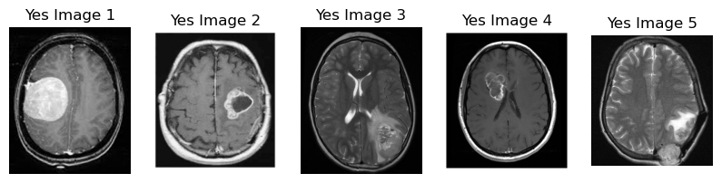

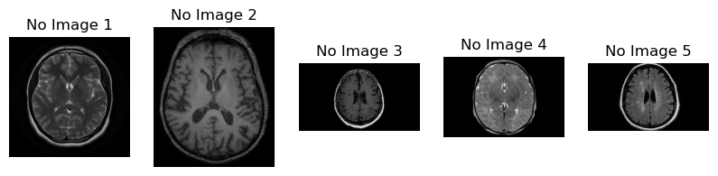

```python
def show_orientations(dataset_path, category, num_samples=5):
    category_path = os.path.join(dataset_path, category)
    image_files = os.listdir(category_path)[:num_samples]

    plt.figure(figsize=(10, 5))
    for i, img_file in enumerate(image_files):
        img_path = os.path.join(category_path, img_file)
        img = Image.open(img_path)

        plt.subplot(1, num_samples, i+1)
        plt.imshow(img, cmap='gray')
        plt.axis("off")
        plt.title(f"{category} Image {i+1}")

    plt.show()

# Check MRI orientations
show_orientations(dataset_path, "Yes", num_samples=5)
show_orientations(dataset_path, "No", num_samples=5)
```

# Potential Noise in Images

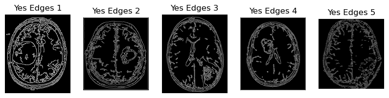

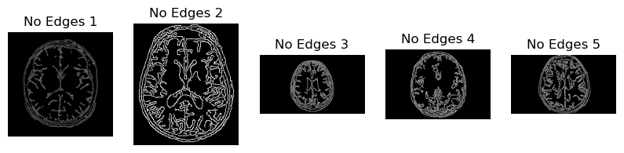

```python
def detect_edges(dataset_path, category, num_samples=5):
    category_path = os.path.join(dataset_path, category)
    image_files = os.listdir(category_path)[:num_samples]

    plt.figure(figsize=(10, 5))
    for i, img_file in enumerate(image_files):
        img_path = os.path.join(category_path, img_file)
        img = cv2.imread(img_path, cv2.IMREAD_GRAYSCALE)
        edges = cv2.Canny(img, 50, 150)  # Canny edge detection

        plt.subplot(1, num_samples, i+1)
        plt.imshow(edges, cmap='gray')
        plt.axis("off")
        plt.title(f"{category} Edges {i+1}")

    plt.show()

# Check noise levels using edge detection
detect_edges(dataset_path, "Yes", num_samples=5)
detect_edges(dataset_path, "No", num_samples=5)
```

The data set does not look that have noisy data.

# Starting the preprocessing code

```python
# Step 1: Convert images to grayscale or RGB as required
def load_image(image_path, grayscale=True):
    image = Image.open(image_path)
    if grayscale:
        image = image.convert('L')  # Convert to grayscale
    else:
        image = image.convert('RGB')  # Convert to RGB
    return image

# Step 2: Resize images to fixed size
def resize_image(image, target_size=(128, 128)):
    image = image.resize(target_size)
    return image

# Step 3: Normalize pixel values (0-255 -> 0-1)
def normalize_image(image):
    image_data = np.array(image).astype('float32')
    image_data /= 255.0  # Normalize to [0, 1]
    return image_data

# Step 4: Encode labels as binary (1 for Tumor, 0 for No Tumor)
def encode_label(category):
    return 1 if category == 'Yes' else 0  # 'Yes' = Tumor, 'No' = No Tumor
```

# Feature Engineering to Enhancing Image Quality

Functions to feature engineering the data set anf to enhace the quality of the images from this data set.

```python
def apply_augmentation(image):
    datagen = ImageDataGenerator(
        rotation_range=20,
        zoom_range=0.2,
        horizontal_flip=True,
        brightness_range=[0.8, 1.2]
    )

    # Ensure image has correct shape (batch_size, height, width, channels)
    img = np.expand_dims(image, axis=0)  # Add batch dimension (1, 128, 128)
    img = np.expand_dims(img, axis=-1)  # Add channel dimension (1, 128, 128, 1)

    it = datagen.flow(img, batch_size=1)

    # Generate 5 augmented images using `next(it)`
    augmented_images = [next(it)[0].squeeze() for _ in range(5)]

    return augmented_images
```

```python
# Load an image
def load_image(image_path, target_size=(128, 128)):
    img = cv2.imread(image_path, cv2.IMREAD_GRAYSCALE)  # Load as grayscale
    img = cv2.resize(img, target_size)  # Resize
    img = img / 255.0  # Normalize pixel values (0-255 -> 0-1)
    return img

# Display multiple images for comparison
def show_images(images, titles, cmap='gray'):
    plt.figure(figsize=(15, 5))
    for i, (img, title) in enumerate(zip(images, titles)):
        plt.subplot(1, len(images), i + 1)
        plt.imshow(img, cmap=cmap)
        plt.title(title)
        plt.axis('off')
    plt.show()
```

```python
# Define the data augmentation generator
datagen = ImageDataGenerator(
    rotation_range=20,          # Rotate image by ±20 degrees
    zoom_range=0.2,             # Zoom in/out by 20%
    horizontal_flip=True,       # Randomly flip images
    brightness_range=[0.8, 1.2] # Adjust brightness
)

# Apply augmentation
def apply_augmentation(image):
    img = img_to_array(image)  # Convert to array
    img = np.expand_dims(img, axis=0)  # Add batch dimension
    it = datagen.flow(img, batch_size=1)

    augmented_images = [it.next()[0].squeeze() for _ in range(5)]  # Generate augmented images
    return augmented_images
```

```python
def apply_edge_detection(image):
    edges = cv2.Canny((image * 255).astype(np.uint8), 100, 200)  # Convert to uint8 & detect edges
    return edges
```

```python
def apply_denoising(image):
    denoised = cv2.GaussianBlur(image, (5, 5), 0)
    return denoised
```

```python
def apply_contrast_enhancement(image):
    clahe = cv2.createCLAHE(clipLimit=2.0, tileGridSize=(8, 8))
    image_equalized = clahe.apply((image * 255).astype(np.uint8))  # Convert back to uint8
    return image_equalized
```

# Building the CNN Model

## Creating CNN Model:

```python
# Define CNN Model
model = Sequential([
    # First Convolutional Block
    Conv2D(32, (3,3), activation='relu', input_shape=(128,128,3)),
    MaxPooling2D(2,2),
    BatchNormalization(),

    # Second Convolutional Block
    Conv2D(64, (3,3), activation='relu'),
    MaxPooling2D(2,2),
    BatchNormalization(),

    # Flatten and Fully Connected Layers
    Flatten(),
    Dense(128, activation='relu'),
    Dropout(0.5),
    Dense(1, activation='sigmoid')  # Binary classification output
])

# Compile the model
model.compile(optimizer='adam', loss='binary_crossentropy', metrics=['accuracy'])

# Print model summary
model.summary()
model.save("brain_tumor_model.h5")
```

```
Model: "sequential"
```

```
┏━━━━━━━━━━━━━━━━━━━━━━━━━━━━━━━━━━━━━━┳━━━━━━━━━━━━━━━━━━━━━━━━━━━━━┳━━━━━━━━━━━━━━━━━┓
┃ Layer (type)                         ┃ Output Shape                ┃         Param # ┃
┡━━━━━━━━━━━━━━━━━━━━━━━━━━━━━━━━━━━━━━╇━━━━━━━━━━━━━━━━━━━━━━━━━━━━━╇━━━━━━━━━━━━━━━━━┩
│ conv2d (Conv2D)                      │ (None, 126, 126, 32)        │             896 │
├──────────────────────────────────────┼─────────────────────────────┼─────────────────┤
│ max_pooling2d (MaxPooling2D)         │ (None, 63, 63, 32)          │               0 │
├──────────────────────────────────────┼─────────────────────────────┼─────────────────┤
│ batch_normalization                  │ (None, 63, 63, 32)          │             128 │
│ (BatchNormalization)                 │                             │                 │
├──────────────────────────────────────┼─────────────────────────────┼─────────────────┤
│ conv2d_1 (Conv2D)                    │ (None, 61, 61, 64)          │          18,496 │
├──────────────────────────────────────┼─────────────────────────────┼─────────────────┤
│ max_pooling2d_1 (MaxPooling2D)       │ (None, 30, 30, 64)          │               0 │
├──────────────────────────────────────┼─────────────────────────────┼─────────────────┤
│ batch_normalization_1                │ (None, 30, 30, 64)          │             256 │
│ (BatchNormalization)                 │                             │                 │
├──────────────────────────────────────┼─────────────────────────────┼─────────────────┤
│ flatten (Flatten)                    │ (None, 57600)               │               0 │
├──────────────────────────────────────┼─────────────────────────────┼─────────────────┤
│ dense (Dense)                        │ (None, 128)                 │       7,372,928 │
├──────────────────────────────────────┼─────────────────────────────┼─────────────────┤
│ dropout (Dropout)                    │ (None, 128)                 │               0 │
├──────────────────────────────────────┼─────────────────────────────┼─────────────────┤
│ dense_1 (Dense)                      │ (None, 1)                   │             129 │
└──────────────────────────────────────┴─────────────────────────────┴─────────────────┘
```

```
 Total params: 7,392,833 (28.20 MB)
```

```
 Trainable params: 7,392,641 (28.20 MB)
```

```
 Non-trainable params: 192 (768.00 B)
```

```
WARNING:absl:You are saving your model as an HDF5 file via `model.save()` or `keras.saving.save_model(model)`. This file format is considered legacy. We recommend using instead the native Keras format, e.g. `model.save('my_model.keras')` or `keras.saving.save_model(model, 'my_model.keras')`.
```

```python
datagen = ImageDataGenerator(
    rescale=1./255,
    rotation_range=20,
    zoom_range=0.2,
    horizontal_flip=True,
    validation_split=0.2
)
```

## Spliting images into 3 folders: Validation, Train and Test

### After the model creation the data set will be diveded into 3 cateogries, Train 80%, Test 10% and Validation 10%.

```python
import os
from sklearn.model_selection import train_test_split
import shutil

dataset_path = r"C:\data\brain_tumor_dataset"
train_dir = os.path.join(dataset_path, "train")
val_dir = os.path.join(dataset_path, "validation")
test_dir = os.path.join(dataset_path, "test")

# Create directories if they don't exist
os.makedirs(train_dir, exist_ok=True)
os.makedirs(val_dir, exist_ok=True)
os.makedirs(test_dir, exist_ok=True)

# Loop through each class folder (yes/no)
for class_folder in os.listdir(dataset_path):
    class_path = os.path.join(dataset_path, class_folder)
    if os.path.isdir(class_path):
        images = os.listdir(class_path)

        # Skip class if there are not enough images (less than 2 images in a class)
        if len(images) < 2:
            print(f"Not enough images in '{class_folder}' class. Skipping...")
            continue

        # Split images into train and temp (validation + test)
        train_images, temp_images = train_test_split(images, test_size=0.2, random_state=42)

        # Further split temp_images into validation and test sets (10% each)
        val_images, test_images = train_test_split(temp_images, test_size=0.5, random_state=42)

        # Create class-specific directories for train, validation, and test
        os.makedirs(os.path.join(train_dir, class_folder), exist_ok=True)
        os.makedirs(os.path.join(val_dir, class_folder), exist_ok=True)
        os.makedirs(os.path.join(test_dir, class_folder), exist_ok=True)

        # Move images to the corresponding directories
        for img in train_images:
            shutil.move(os.path.join(class_path, img), os.path.join(train_dir, class_folder, img))
        for img in val_images:
            shutil.move(os.path.join(class_path, img), os.path.join(val_dir, class_folder, img))
        for img in test_images:
            shutil.move(os.path.join(class_path, img), os.path.join(test_dir, class_folder, img))
```

```
Not enough images in 'no' class. Skipping...
Not enough images in 'test' class. Skipping...
Not enough images in 'train' class. Skipping...
Not enough images in 'validation' class. Skipping...
```

```python
import os
from sklearn.model_selection import train_test_split
import shutil

dataset_path = r"C:\data\brain_tumor_dataset"
train_dir = os.path.join(dataset_path, "train")
val_dir = os.path.join(dataset_path, "validation")
test_dir = os.path.join(dataset_path, "test")

# Create directories if they don't exist
os.makedirs(train_dir, exist_ok=True)
os.makedirs(val_dir, exist_ok=True)
os.makedirs(test_dir, exist_ok=True)

# Specifically handle the 'yes' class
class_folder = 'yes'  # Set the folder you want to handle

class_path = os.path.join(dataset_path, class_folder)
if os.path.isdir(class_path):
    images = os.listdir(class_path)

    # Skip class if there are not enough images (less than 2 images in a class)
    if len(images) < 2:
        print(f"Not enough images in '{class_folder}' class. Skipping...")
    else:
        # Split images into train and temp (validation + test)
        train_images, temp_images = train_test_split(images, test_size=0.2, random_state=42)

        # Further split temp_images into validation and test sets (10% each)
        val_images, test_images = train_test_split(temp_images, test_size=0.5, random_state=42)

        # Create class-specific directories for train, validation, and test
        os.makedirs(os.path.join(train_dir, class_folder), exist_ok=True)
        os.makedirs(os.path.join(val_dir, class_folder), exist_ok=True)
        os.makedirs(os.path.join(test_dir, class_folder), exist_ok=True)

        # Move images to the corresponding directories
        for img in train_images:
            shutil.move(os.path.join(class_path, img), os.path.join(train_dir, class_folder, img))
        for img in val_images:
            shutil.move(os.path.join(class_path, img), os.path.join(val_dir, class_folder, img))
        for img in test_images:
            shutil.move(os.path.join(class_path, img), os.path.join(test_dir, class_folder, img))

print("Processing completed for 'yes' class.")
```

```
Not enough images in 'yes' class. Skipping...
Processing completed for 'yes' class.
```

# Model Training & Evaluation

Staring the model training and validation

```python
from tensorflow.keras.preprocessing.image import ImageDataGenerator
import tensorflow as tf
from tensorflow import keras
from tensorflow.keras.models import save_model

# Initialize the ImageDataGenerator
datagen = ImageDataGenerator(rescale=1./255)  # Rescale pixel values to [0, 1]

# Set paths for the training and validation directories
train_dir = r"C:\data\brain_tumor_dataset\train"
val_dir = r"C:\data\brain_tumor_dataset\validation"

# Create train and validation generators
train_generator = datagen.flow_from_directory(
    train_dir,
    target_size=(128, 128),  # Resize images to 128x128
    batch_size=32,
    class_mode='binary'  # For binary classification (Yes/No)
)

val_generator = datagen.flow_from_directory(
    val_dir,
    target_size=(128, 128),  # Resize images to 128x128
    batch_size=32,
    class_mode='binary'  # For binary classification (Yes/No)
)

# Define the model (for example, a simple CNN)
from tensorflow.keras.models import Sequential
from tensorflow.keras.layers import Conv2D, MaxPooling2D, Flatten, Dense

model = Sequential([
    Conv2D(32, (3, 3), activation='relu', input_shape=(128, 128, 3)),
    MaxPooling2D((2, 2)),
    Flatten(),
    Dense(128, activation='relu'),
    Dense(1, activation='sigmoid')  # Sigmoid activation for binary classification
])

# Compile the model
model.compile(optimizer='adam', loss='binary_crossentropy', metrics=['accuracy'])

# Fit the model
history = model.fit(
    train_generator,  # Training Data
    validation_data=val_generator,  # Validation Data
    epochs=20,  # Number of epochs
    verbose=1  # Show training progress
)
# Save the model in .h5 format
model.save(r"C:\data\brain_tumor_model.h5")
model.save('brain_tumor_model.keras')
```

```
Found 202 images belonging to 2 classes.
Found 25 images belonging to 2 classes.
```

```
7/7 ━━━━━━━━━━━━━━━━━━━━ 3s 297ms/step - accuracy: 0.6003 - loss: 4.6030 - val_accuracy: 0.8000 - val_loss: 1.5202
7/7 ━━━━━━━━━━━━━━━━━━━━ 2s 262ms/step - accuracy: 0.7455 - loss: 1.8274 - val_accuracy: 0.6800 - val_loss: 1.0069
7/7 ━━━━━━━━━━━━━━━━━━━━ 2s 271ms/step - accuracy: 0.7406 - loss: 0.7730 - val_accuracy: 0.8400 - val_loss: 0.3870
7/7 ━━━━━━━━━━━━━━━━━━━━ 2s 251ms/step - accuracy: 0.7809 - loss: 0.5482 - val_accuracy: 0.8400 - val_loss: 0.2876
7/7 ━━━━━━━━━━━━━━━━━━━━ 2s 263ms/step - accuracy: 0.9080 - loss: 0.2899 - val_accuracy: 0.9600 - val_loss: 0.2117
7/7 ━━━━━━━━━━━━━━━━━━━━ 2s 254ms/step - accuracy: 0.9463 - loss: 0.2018 - val_accuracy: 0.9600 - val_loss: 0.1740
7/7 ━━━━━━━━━━━━━━━━━━━━ 2s 250ms/step - accuracy: 0.9700 - loss: 0.1345 - val_accuracy: 0.9200 - val_loss: 0.2053
7/7 ━━━━━━━━━━━━━━━━━━━━ 2s 248ms/step - accuracy: 1.0000 - loss: 0.0930 - val_accuracy: 0.9600 - val_loss: 0.1887
7/7 ━━━━━━━━━━━━━━━━━━━━ 2s 245ms/step - accuracy: 0.9884 - loss: 0.0678 - val_accuracy: 0.9200 - val_loss: 0.1922
7/7 ━━━━━━━━━━━━━━━━━━━━ 2s 264ms/step - accuracy: 1.0000 - loss: 0.0306 - val_accuracy: 0.9600 - val_loss: 0.1717
7/7 ━━━━━━━━━━━━━━━━━━━━ 2s 261ms/step - accuracy: 1.0000 - loss: 0.0237 - val_accuracy: 0.9200 - val_loss: 0.1583
7/7 ━━━━━━━━━━━━━━━━━━━━ 2s 258ms/step - accuracy: 1.0000 - loss: 0.0174 - val_accuracy: 0.9600 - val_loss: 0.1500
7/7 ━━━━━━━━━━━━━━━━━━━━ 2s 257ms/step - accuracy: 1.0000 - loss: 0.0130 - val_accuracy: 0.9600 - val_loss: 0.1495
7/7 ━━━━━━━━━━━━━━━━━━━━ 2s 257ms/step - accuracy: 1.0000 - loss: 0.0101 - val_accuracy: 0.9200 - val_loss: 0.1539
7/7 ━━━━━━━━━━━━━━━━━━━━ 2s 243ms/step - accuracy: 1.0000 - loss: 0.0072 - val_accuracy: 0.9200 - val_loss: 0.1609
7/7 ━━━━━━━━━━━━━━━━━━━━ 2s 277ms/step - accuracy: 1.0000 - loss: 0.0066 - val_accuracy: 0.9200 - val_loss: 0.1673
7/7 ━━━━━━━━━━━━━━━━━━━━ 2s 261ms/step - accuracy: 1.0000 - loss: 0.0057 - val_accuracy: 0.9200 - val_loss: 0.1740
7/7 ━━━━━━━━━━━━━━━━━━━━ 2s 265ms/step - accuracy: 1.0000 - loss: 0.0043 - val_accuracy: 0.9200 - val_loss: 0.1769
7/7 ━━━━━━━━━━━━━━━━━━━━ 2s 263ms/step - accuracy: 1.0000 - loss: 0.0038 - val_accuracy: 0.9200 - val_loss: 0.1795
7/7 ━━━━━━━━━━━━━━━━━━━━ 2s 257ms/step - accuracy: 1.0000 - loss: 0.0032 - val_accuracy: 0.9200 - val_loss: 0.1777
```

```
WARNING:absl:You are saving your model as an HDF5 file via `model.save()` or `keras.saving.save_model(model)`. This file format is considered legacy. We recommend using instead the native Keras format, e.g. `model.save('my_model.keras')` or `keras.saving.save_model(model, 'my_model.keras')`.
```

[figure not shown]

```python
# Extract accuracy and loss values
train_acc = history.history['accuracy']
val_acc = history.history['val_accuracy']
train_loss = history.history['loss']
val_loss = history.history['val_loss']
epochs = range(1, len(train_acc) + 1)

# Plot Accuracy
plt.figure(figsize=(12, 4))
plt.subplot(1, 2, 1)
plt.plot(epochs, train_acc, 'b', label='Training Accuracy')
plt.plot(epochs, val_acc, 'r', label='Validation Accuracy')
plt.xlabel('Epochs')
plt.ylabel('Accuracy')
plt.legend()
plt.title('Training vs. Validation Accuracy')

# Plot Loss
plt.subplot(1, 2, 2)
plt.plot(epochs, train_loss, 'b', label='Training Loss')
plt.plot(epochs, val_loss, 'r', label='Validation Loss')
plt.xlabel('Epochs')
plt.ylabel('Loss')
plt.legend()
plt.title('Training vs. Validation Loss')

plt.show()
```

Outputting the model accuracy with matrix confusion and main metrics:

```
Found 202 images belonging to 2 classes.
Found 25 images belonging to 2 classes.
Found 26 images belonging to 2 classes.
7/7 ━━━━━━━━━━━━━━━━━━━━ 4s 428ms/step - accuracy: 0.5275 - loss: 1.7182 - val_accuracy: 0.6400 - val_loss: 0.5647
7/7 ━━━━━━━━━━━━━━━━━━━━ 3s 389ms/step - accuracy: 0.5106 - loss: 0.7263 - val_accuracy: 0.6400 - val_loss: 0.6150
7/7 ━━━━━━━━━━━━━━━━━━━━ 2s 321ms/step - accuracy: 0.5807 - loss: 0.6763 - val_accuracy: 0.6000 - val_loss: 0.5975
7/7 ━━━━━━━━━━━━━━━━━━━━ 3s 362ms/step - accuracy: 0.6379 - loss: 0.6427 - val_accuracy: 0.6400 - val_loss: 0.5613
7/7 ━━━━━━━━━━━━━━━━━━━━ 3s 378ms/step - accuracy: 0.7211 - loss: 0.6150 - val_accuracy: 0.8000 - val_loss: 0.5371
7/7 ━━━━━━━━━━━━━━━━━━━━ 3s 348ms/step - accuracy: 0.7481 - loss: 0.5698 - val_accuracy: 0.8400 - val_loss: 0.4762
7/7 ━━━━━━━━━━━━━━━━━━━━ 3s 371ms/step - accuracy: 0.7252 - loss: 0.5737 - val_accuracy: 0.8000 - val_loss: 0.4143
7/7 ━━━━━━━━━━━━━━━━━━━━ 3s 347ms/step - accuracy: 0.6902 - loss: 0.6021 - val_accuracy: 0.7600 - val_loss: 0.4295
7/7 ━━━━━━━━━━━━━━━━━━━━ 3s 356ms/step - accuracy: 0.6665 - loss: 0.6365 - val_accuracy: 0.6400 - val_loss: 0.4853
7/7 ━━━━━━━━━━━━━━━━━━━━ 3s 372ms/step - accuracy: 0.7042 - loss: 0.6080 - val_accuracy: 0.9200 - val_loss: 0.4785
7/7 ━━━━━━━━━━━━━━━━━━━━ 3s 406ms/step - accuracy: 0.7301 - loss: 0.5871 - val_accuracy: 0.7600 - val_loss: 0.4407
7/7 ━━━━━━━━━━━━━━━━━━━━ 2s 329ms/step - accuracy: 0.7488 - loss: 0.5420 - val_accuracy: 0.9200 - val_loss: 0.3194
7/7 ━━━━━━━━━━━━━━━━━━━━ 3s 346ms/step - accuracy: 0.7055 - loss: 0.5884 - val_accuracy: 0.8400 - val_loss: 0.3169
7/7 ━━━━━━━━━━━━━━━━━━━━ 3s 354ms/step - accuracy: 0.7341 - loss: 0.5643 - val_accuracy: 0.8800 - val_loss: 0.2946
7/7 ━━━━━━━━━━━━━━━━━━━━ 3s 353ms/step - accuracy: 0.7348 - loss: 0.5592 - val_accuracy: 0.8400 - val_loss: 0.3537
7/7 ━━━━━━━━━━━━━━━━━━━━ 3s 348ms/step - accuracy: 0.7022 - loss: 0.5922 - val_accuracy: 0.9600 - val_loss: 0.4034
7/7 ━━━━━━━━━━━━━━━━━━━━ 3s 340ms/step - accuracy: 0.7382 - loss: 0.5720 - val_accuracy: 0.9200 - val_loss: 0.3370
7/7 ━━━━━━━━━━━━━━━━━━━━ 2s 337ms/step - accuracy: 0.7535 - loss: 0.5065 - val_accuracy: 0.8800 - val_loss: 0.3021
7/7 ━━━━━━━━━━━━━━━━━━━━ 3s 346ms/step - accuracy: 0.7627 - loss: 0.5321 - val_accuracy: 0.9200 - val_loss: 0.2730
7/7 ━━━━━━━━━━━━━━━━━━━━ 3s 351ms/step - accuracy: 0.7345 - loss: 0.5017 - val_accuracy: 0.9200 - val_loss: 0.3157
```

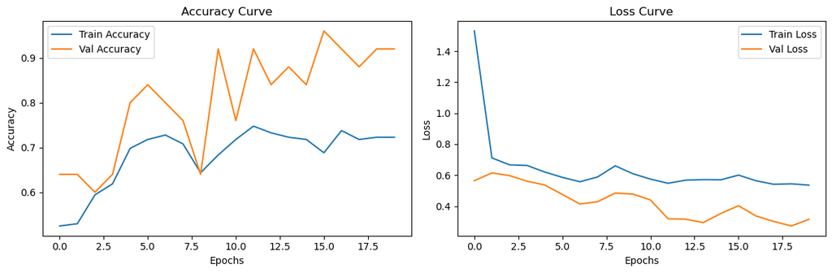

```
1/1 ━━━━━━━━━━━━━━━━━━━━ 0s 130ms/step - accuracy: 0.7692 - loss: 0.5984
Test Accuracy: 0.77
Test Loss: 0.60
1/1 ━━━━━━━━━━━━━━━━━━━━ 0s 183ms/step

Classification Report:
               precision    recall  f1-score   support

           0       0.67      0.80      0.73        10
           1       0.86      0.75      0.80        16

    accuracy                           0.77        26
   macro avg       0.76      0.78      0.76        26
weighted avg       0.78      0.77      0.77        26
```

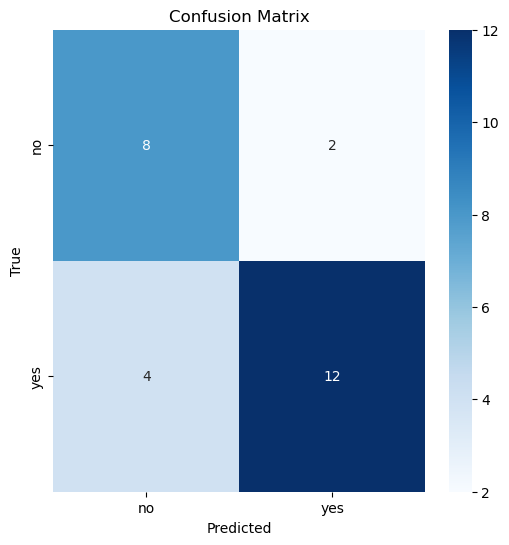

```python
# Paths for training, validation, and test sets
train_dir = 'C:/data/brain_tumor_dataset/train'
val_dir = 'C:/data/brain_tumor_dataset/validation'
test_dir = r'C:/data/brain_tumor_dataset/test'

# Image data generators for data augmentation and loading
train_datagen = ImageDataGenerator(rescale=1./255, rotation_range=30, width_shift_range=0.2, height_shift_range=0.2, shear_range=0.2, zoom_range=0.2, horizontal_flip=True, fill_mode='nearest')
val_datagen = ImageDataGenerator(rescale=1./255)
test_datagen = ImageDataGenerator(rescale=1./255)

train_data = train_datagen.flow_from_directory(train_dir, target_size=(128, 128), batch_size=32, class_mode='binary')
val_data = val_datagen.flow_from_directory(val_dir, target_size=(128, 128), batch_size=32, class_mode='binary')
test_data = test_datagen.flow_from_directory(test_dir, target_size=(128, 128), batch_size=32, class_mode='binary', shuffle=False)

# Define CNN Model
model = Sequential([
    Conv2D(32, (3, 3), activation='relu', input_shape=(128, 128, 3)),
    MaxPooling2D(2, 2),
    Conv2D(64, (3, 3), activation='relu'),
    MaxPooling2D(2, 2),
    Flatten(),
    Dense(128, activation='relu'),
    Dropout(0.5),
    Dense(1, activation='sigmoid')  # Binary classification (yes/no)
])

# Compile the model
model.compile(optimizer='adam', loss='binary_crossentropy', metrics=['accuracy'])

# Train the model
history = model.fit(train_data, validation_data=val_data, epochs=20)

# Plot accuracy and loss curves
plt.figure(figsize=(12, 4))

# Accuracy plot
plt.subplot(1, 2, 1)
plt.plot(history.history['accuracy'], label='Train Accuracy')
plt.plot(history.history['val_accuracy'], label='Val Accuracy')
plt.title('Accuracy Curve')
plt.xlabel('Epochs')
plt.ylabel('Accuracy')
plt.legend()

# Loss plot
plt.subplot(1, 2, 2)
plt.plot(history.history['loss'], label='Train Loss')
plt.plot(history.history['val_loss'], label='Val Loss')
plt.title('Loss Curve')
plt.xlabel('Epochs')
plt.ylabel('Loss')
plt.legend()

plt.tight_layout()
plt.show()

# Evaluate the model on the test set
test_loss, test_accuracy = model.evaluate(test_data)
print(f"Test Accuracy: {test_accuracy:.2f}")
print(f"Test Loss: {test_loss:.2f}")

# Predict on test data
y_pred = model.predict(test_data)
y_pred_classes = (y_pred > 0.5).astype(int)

# True labels
y_true = test_data.classes

# Classification Report
print("\nClassification Report:\n", classification_report(y_true, y_pred_classes))

# Confusion Matrix
conf_matrix = confusion_matrix(y_true, y_pred_classes)
plt.figure(figsize=(6, 6))
sns.heatmap(conf_matrix, annot=True, fmt='d', cmap='Blues', xticklabels=train_data.class_indices, yticklabels=train_data.class_indices)
plt.title('Confusion Matrix')
plt.xlabel('Predicted')
plt.ylabel('True')
plt.show()
```

### Outcome of the model

#### Precision:

67% of the instances predicted as class 0(NO TUMOR) are actually class 0 (NO TUMOR), 86% of the instances predicted as class 1(YES TUMOR) are actually class 1( YES TUMOR).

#### Recall:

80% of the actual class 0 (NO TUMOR) instances were correctly predicted. 75% of the actual class 1 (YES TUMOR) instances were correctly predicted.

#### F1-SCORE:

For class 0 (NO TUMOR): The F1-Score is 0.73. For class 1(YES TUMOR): The F1-Score is 0.80.

#### Accuracy:

0.77 (77%), meaning the model correctly predicted 77% of the instances in the dataset.

# Model Fine-Tuning

Tunning the model for better prediction

```python
# Paths for training, validation, and test sets
train_dir = 'C:/data/brain_tumor_dataset/train'
val_dir = 'C:/data/brain_tumor_dataset/validation'
test_dir = r'C:/data/brain_tumor_dataset/test'

# Image data generators for data augmentation and loading
train_datagen = ImageDataGenerator(rescale=1./255, rotation_range=30, width_shift_range=0.2, height_shift_range=0.2, shear_range=0.2, zoom_range=0.2, horizontal_flip=True, fill_mode='nearest')
val_datagen = ImageDataGenerator(rescale=1./255)
test_datagen = ImageDataGenerator(rescale=1./255)

train_data = train_datagen.flow_from_directory(train_dir, target_size=(128, 128), batch_size=32, class_mode='binary')
val_data = val_datagen.flow_from_directory(val_dir, target_size=(128, 128), batch_size=32, class_mode='binary')
test_data = test_datagen.flow_from_directory(test_dir, target_size=(128, 128), batch_size=32, class_mode='binary', shuffle=False)
```

```
Found 202 images belonging to 2 classes.
Found 25 images belonging to 2 classes.
Found 26 images belonging to 2 classes.
```

```python
def create_model(optimizer, dropout_rate, learning_rate):
    model = Sequential([
        Conv2D(32, (3, 3), activation='relu', input_shape=(128, 128, 3)),
        MaxPooling2D(2, 2),
        Conv2D(64, (3, 3), activation='relu'),
        MaxPooling2D(2, 2),
        Flatten(),
        Dense(128, activation='relu'),
        Dropout(dropout_rate),  # Experiment with different dropout rates
        Dense(1, activation='sigmoid')  # Binary classification
    ])

    # Choose optimizer based on input
    if optimizer == 'adam':
        opt = Adam(learning_rate=learning_rate)
    elif optimizer == 'sgd':
        opt = SGD(learning_rate=learning_rate)
    elif optimizer == 'rmsprop':
        opt = RMSprop(learning_rate=learning_rate)

    model.compile(optimizer=opt, loss='binary_crossentropy', metrics=['accuracy'])
    return model

# Define hyperparameters to experiment with
batch_sizes = [16, 32, 64]
optimizers = ['adam', 'sgd', 'rmsprop']
dropout_rates = [0.2, 0.5, 0.7]
learning_rates = [0.001, 0.0001, 0.01]

best_val_accuracy = 0
best_hyperparams = {}

# Loop over different combinations of hyperparameters
for batch_size in batch_sizes:
    for optimizer in optimizers:
        for dropout_rate in dropout_rates:
            for learning_rate in learning_rates:
                print(f"\nTraining with batch_size={batch_size}, optimizer={optimizer}, dropout_rate={dropout_rate}, learning_rate={learning_rate}")

                # Create the model with current hyperparameters
                model = create_model(optimizer=optimizer, dropout_rate=dropout_rate, learning_rate=learning_rate)

                # Early stopping to avoid overfitting
                early_stopping = EarlyStopping(monitor='val_loss', patience=3, restore_best_weights=True)

                # Train the model
                history = model.fit(train_data, validation_data=val_data, epochs=20, batch_size=batch_size, callbacks=[early_stopping])

                # Get the validation accuracy and check if it's the best so far
                val_accuracy = max(history.history['val_accuracy'])

                if val_accuracy > best_val_accuracy:
                    best_val_accuracy = val_accuracy
                    best_hyperparams = {
                        'batch_size': batch_size,
                        'optimizer': optimizer,
                        'dropout_rate': dropout_rate,
                        'learning_rate': learning_rate
                    }
                print(f"Validation Accuracy: {val_accuracy:.4f}")

# Print the best hyperparameters and their corresponding accuracy
print("\nBest Hyperparameters:")
print(best_hyperparams)
print(f"Best Validation Accuracy: {best_val_accuracy:.4f}")
```

```
Training with batch_size=16, optimizer=adam, dropout_rate=0.2, learning_rate=0.001
7/7 ━━━━━━━━━━━━━━━━━━━━ 4s 402ms/step - accuracy: 0.4433 - loss: 1.2059 - val_accuracy: 0.6000 - val_loss: 0.5808
7/7 ━━━━━━━━━━━━━━━━━━━━ 2s 297ms/step - accuracy: 0.5721 - loss: 0.6746 - val_accuracy: 0.8000 - val_loss: 0.6545
7/7 ━━━━━━━━━━━━━━━━━━━━ 2s 317ms/step - accuracy: 0.6823 - loss: 0.6740 - val_accuracy: 0.6000 - val_loss: 0.6169
7/7 ━━━━━━━━━━━━━━━━━━━━ 2s 338ms/step - accuracy: 0.6057 - loss: 0.6424 - val_accuracy: 0.6000 - val_loss: 0.5582
7/7 ━━━━━━━━━━━━━━━━━━━━ 2s 327ms/step - accuracy: 0.6766 - loss: 0.6054 - val_accuracy: 0.8400 - val_loss: 0.5694
7/7 ━━━━━━━━━━━━━━━━━━━━ 2s 303ms/step - accuracy: 0.6102 - loss: 0.6341 - val_accuracy: 0.6400 - val_loss: 0.5046
7/7 ━━━━━━━━━━━━━━━━━━━━ 2s 339ms/step - accuracy: 0.6642 - loss: 0.6003 - val_accuracy: 0.9200 - val_loss: 0.4778
7/7 ━━━━━━━━━━━━━━━━━━━━ 2s 297ms/step - accuracy: 0.7002 - loss: 0.6018 - val_accuracy: 0.8400 - val_loss: 0.4776
7/7 ━━━━━━━━━━━━━━━━━━━━ 2s 308ms/step - accuracy: 0.7320 - loss: 0.5767 - val_accuracy: 0.8800 - val_loss: 0.4729
7/7 ━━━━━━━━━━━━━━━━━━━━ 2s 302ms/step - accuracy: 0.7106 - loss: 0.5938 - val_accuracy: 0.6800 - val_loss: 0.4268
7/7 ━━━━━━━━━━━━━━━━━━━━ 2s 321ms/step - accuracy: 0.7386 - loss: 0.5895 - val_accuracy: 0.8800 - val_loss: 0.3249
7/7 ━━━━━━━━━━━━━━━━━━━━ 2s 335ms/step - accuracy: 0.6962 - loss: 0.6093 - val_accuracy: 0.8800 - val_loss: 0.3268
7/7 ━━━━━━━━━━━━━━━━━━━━ 2s 296ms/step - accuracy: 0.7038 - loss: 0.5411 - val_accuracy: 0.9200 - val_loss: 0.3083
7/7 ━━━━━━━━━━━━━━━━━━━━ 2s 313ms/step - accuracy: 0.7241 - loss: 0.5731 - val_accuracy: 0.8400 - val_loss: 0.3317
7/7 ━━━━━━━━━━━━━━━━━━━━ 2s 312ms/step - accuracy: 0.6936 - loss: 0.5710 - val_accuracy: 0.8800 - val_loss: 0.3247
7/7 ━━━━━━━━━━━━━━━━━━━━ 2s 310ms/step - accuracy: 0.7245 - loss: 0.5409 - val_accuracy: 0.9200 - val_loss: 0.3090
Validation Accuracy: 0.9200

Training with batch_size=16, optimizer=adam, dropout_rate=0.2, learning_rate=0.0001
7/7 ━━━━━━━━━━━━━━━━━━━━ 4s 383ms/step - accuracy: 0.5651 - loss: 0.6645 - val_accuracy: 0.6400 - val_loss: 0.5313
7/7 ━━━━━━━━━━━━━━━━━━━━ 5s 338ms/step - accuracy: 0.6375 - loss: 0.6148 - val_accuracy: 0.8000 - val_loss: 0.5008
7/7 ━━━━━━━━━━━━━━━━━━━━ 2s 301ms/step - accuracy: 0.7026 - loss: 0.6112 - val_accuracy: 0.8000 - val_loss: 0.4787
7/7 ━━━━━━━━━━━━━━━━━━━━ 2s 296ms/step - accuracy: 0.6748 - loss: 0.6112 - val_accuracy: 0.8000 - val_loss: 0.4591
7/7 ━━━━━━━━━━━━━━━━━━━━ 2s 332ms/step - accuracy: 0.6925 - loss: 0.6265 - val_accuracy: 0.7600 - val_loss: 0.4426
7/7 ━━━━━━━━━━━━━━━━━━━━ 2s 320ms/step - accuracy: 0.7216 - loss: 0.5864 - val_accuracy: 0.8000 - val_loss: 0.4377
7/7 ━━━━━━━━━━━━━━━━━━━━ 2s 317ms/step - accuracy: 0.7100 - loss: 0.6033 - val_accuracy: 0.8000 - val_loss: 0.4300
7/7 ━━━━━━━━━━━━━━━━━━━━ 2s 322ms/step - accuracy: 0.6847 - loss: 0.6031 - val_accuracy: 0.7600 - val_loss: 0.4492
7/7 ━━━━━━━━━━━━━━━━━━━━ 2s 353ms/step - accuracy: 0.6023 - loss: 0.6286 - val_accuracy: 0.8800 - val_loss: 0.4131
7/7 ━━━━━━━━━━━━━━━━━━━━ 2s 323ms/step - accuracy: 0.7018 - loss: 0.5565 - val_accuracy: 0.8400 - val_loss: 0.3910
7/7 ━━━━━━━━━━━━━━━━━━━━ 3s 352ms/step - accuracy: 0.7863 - loss: 0.5361 - val_accuracy: 0.8400 - val_loss: 0.3915
7/7 ━━━━━━━━━━━━━━━━━━━━ 2s 382ms/step - accuracy: 0.7014 - loss: 0.5855 - val_accuracy: 0.8800 - val_loss: 0.3904
7/7 ━━━━━━━━━━━━━━━━━━━━ 3s 448ms/step - accuracy: 0.6823 - loss: 0.5582 - val_accuracy: 0.8400 - val_loss: 0.3892
7/7 ━━━━━━━━━━━━━━━━━━━━ 3s 493ms/step - accuracy: 0.6811 - loss: 0.5704 - val_accuracy: 0.8800 - val_loss: 0.3868
7/7 ━━━━━━━━━━━━━━━━━━━━ 3s 343ms/step - accuracy: 0.6513 - loss: 0.5706 - val_accuracy: 0.8800 - val_loss: 0.3883
7/7 ━━━━━━━━━━━━━━━━━━━━ 3s 356ms/step - accuracy: 0.6864 - loss: 0.5604 - val_accuracy: 0.8000 - val_loss: 0.3916
7/7 ━━━━━━━━━━━━━━━━━━━━ 3s 352ms/step - accuracy: 0.7015 - loss: 0.5697 - val_accuracy: 0.8800 - val_loss: 0.3736
7/7 ━━━━━━━━━━━━━━━━━━━━ 3s 353ms/step - accuracy: 0.7001 - loss: 0.5743 - val_accuracy: 0.8400 - val_loss: 0.3838
7/7 ━━━━━━━━━━━━━━━━━━━━ 2s 338ms/step - accuracy: 0.7023 - loss: 0.5534 - val_accuracy: 0.8400 - val_loss: 0.3734
7/7 ━━━━━━━━━━━━━━━━━━━━ 3s 342ms/step - accuracy: 0.6910 - loss: 0.5680 - val_accuracy: 0.8400 - val_loss: 0.3761
```

[output cut: 1298 more lines]

```
7/7 ━━━━━━━━━━━━━━━━━━━━ 3s 372ms/step - accuracy: 0.7280 - loss: 0.5910 - val_accuracy: 0.8400 - val_loss: 0.4661
7/7 ━━━━━━━━━━━━━━━━━━━━ 3s 415ms/step - accuracy: 0.7278 - loss: 0.5644 - val_accuracy: 0.8000 - val_loss: 0.4571
7/7 ━━━━━━━━━━━━━━━━━━━━ 3s 415ms/step - accuracy: 0.6819 - loss: 0.5910 - val_accuracy: 0.8000 - val_loss: 0.4707
Validation Accuracy: 0.8400

Training with batch_size=64, optimizer=rmsprop, dropout_rate=0.7, learning_rate=0.01
7/7 ━━━━━━━━━━━━━━━━━━━━ 6s 555ms/step - accuracy: 0.5033 - loss: 19.9629 - val_accuracy: 0.6000 - val_loss: 0.6324
7/7 ━━━━━━━━━━━━━━━━━━━━ 3s 399ms/step - accuracy: 0.5848 - loss: 0.6994 - val_accuracy: 0.6000 - val_loss: 0.6784
7/7 ━━━━━━━━━━━━━━━━━━━━ 3s 387ms/step - accuracy: 0.6415 - loss: 0.6695 - val_accuracy: 0.6000 - val_loss: 0.6838
7/7 ━━━━━━━━━━━━━━━━━━━━ 3s 405ms/step - accuracy: 0.6242 - loss: 0.6722 - val_accuracy: 0.6000 - val_loss: 0.6744
Validation Accuracy: 0.6000

Best Hyperparameters:
{'batch_size': 16, 'optimizer': 'adam', 'dropout_rate': 0.7, 'learning_rate': 0.001}
Best Validation Accuracy: 0.9600
```

### Best Hyperparameters:

### {'batch_size': 16, 'optimizer': 'adam', 'dropout_rate': 0.7, 'learning_rate': 0.001}

### Best Validation Accuracy: 0.9600

In this data set this is the best parameters to train the model so the next step would be training the model using this and check what would be the increasing of the KPI we're a looking for and see if it's worth to implement using these parameters or the original parameter.

# Output view

Updating the format and loading the model saved.

```python
test_data = tf.keras.utils.image_dataset_from_directory(
    test_data_path,
    image_size=(128, 128),
    batch_size=32,
    shuffle=False
)
```

```
Found 26 files belonging to 2 classes.
```

```python
import tensorflow as tf

# Resize the image before expanding dimensions
img_resized = tf.image.resize(img, (128, 128))

# Expand dimensions to match model input
img_input = np.expand_dims(img_resized, axis=0)

# Make prediction
prediction = model.predict(img_input)
```

```
1/1 ━━━━━━━━━━━━━━━━━━━━ 0s 86ms/step
```

### Saving and loading the model to show a output.

```python
model.save("brain_tumor_model.keras") #saving the model using keras
```

```python
# Loading the model
model = tf.keras.models.load_model("brain_tumor_model.keras")
```

### code to print the output

```
Found 26 files belonging to 2 classes.
Class names: ['no', 'yes']
1/1 ━━━━━━━━━━━━━━━━━━━━ 0s 87ms/step
1/1 ━━━━━━━━━━━━━━━━━━━━ 0s 50ms/step
1/1 ━━━━━━━━━━━━━━━━━━━━ 0s 44ms/step
```

```
1/1 ━━━━━━━━━━━━━━━━━━━━ 0s 46ms/step
```

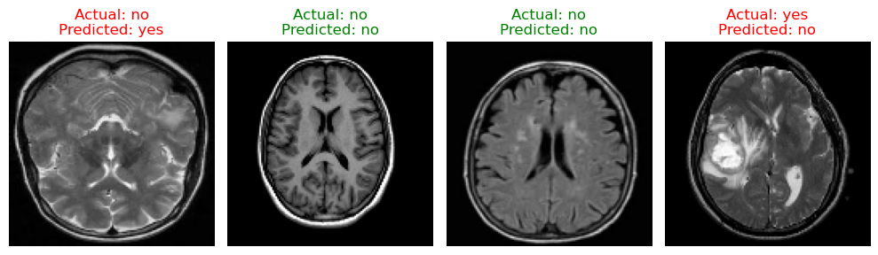

```python
import tensorflow as tf
import matplotlib.pyplot as plt
import numpy as np
import random

# Load the trained model
model = tf.keras.models.load_model("brain_tumor_model.keras")

# Path to test dataset
test_data_path = r'C:/data/brain_tumor_dataset/test'

# Load test dataset
test_data = tf.keras.utils.image_dataset_from_directory(
    test_data_path,
    image_size=(128, 128),  # Ensure this matches your model's input size
    batch_size=32,
    shuffle=False  # Keep order to match labels correctly
)

# Extract images & labels
test_images, test_labels = next(iter(test_data))

# Convert tensors to NumPy arrays
test_images = test_images.numpy()
test_labels = test_labels.numpy()

# Get class names (should be ['no', 'yes'])
class_names = test_data.class_names
print("Class names:", class_names)

# Select 4 random indices
num_images = 4
random_indices = random.sample(range(len(test_images)), num_images)

# Create figure for visualization
plt.figure(figsize=(10, 5))

for i, idx in enumerate(random_indices):
    img = test_images[idx]  # Get image
    true_label = test_labels[idx]  # True class label

    # Preprocess image for model prediction
    img_input = np.expand_dims(img, axis=0)  # Add batch dimension
    prediction = model.predict(img_input)  # Predict class probabilities

    # If using a binary classification model
    if prediction.shape[1] == 1:
        predicted_label = int(prediction[0] > 0.5)  # Convert probability to binary class
    else:
        predicted_label = np.argmax(prediction, axis=1)[0]  # Multiclass case

    # Display image
    plt.subplot(1, num_images, i + 1)
    plt.imshow(img.astype("uint8"))  # Ensure correct display format
    plt.axis("off")

    # Title: Green if correct, Red if incorrect
    title_color = "green" if predicted_label == true_label else "red"
    plt.title(f"Actual: {class_names[true_label]}\nPredicted: {class_names[predicted_label]}", color=title_color)

plt.tight_layout()
plt.show()
```

## Conclusion and last thoughts

In this project, we successfully developed a deep learning model using Convolutional Neural Networks (CNNs) to classify MRI brain scans as tumor or no tumor. The model was trained on a labeled dataset, achieving a test accuracy of 77%, with promising precision and recall scores.

### Key Takeaways

The CNN effectively extracts patterns from MRI scans for classification. Model accuracy can be improved using data augmentation, hyperparameter tuning, or transfer learning. The visualization of test images provides insights into correct and incorrect classifications. Future work could include deploying the model as a web app for real-time predictions.

### Next Steps

Enhance Model Performance – Experiment with pretrained models like VGG16 or ResNet for improved accuracy. Data Augmentation – Apply transformations such as rotation, flipping, and contrast adjustments to improve generalization. Hyperparameter Tuning – Optimize parameters like learning rate, batch size, and dropout rates for better performance. Expand Dataset – Incorporate more MRI images from diverse sources to increase robustness. Model Deployment – Develop a web-based interface using Flask or FastAPI for real-time predictions. Interpretability – Implement techniques like Grad-CAM to visualize how the model makes decisions. By implementing these next steps, we can refine the model to be more accurate, reliable, and useful in medical diagnostics.

### License

This project is licensed under the MIT License. Feel free to use and modify it for research and educational purposes.